# HW5

Pin-wei, Yu

4/3/2020

# The Virus Spreading Simulation

## Case1

Now we set the original parameters.

We assusme that there are 300 people live in the 50*50 unit^2 area and they move once per day with the 2 unit path.

Today, there is a severe virus that once people were infected, the spreading period would last at least 7 days and at most 21 days.

The virus infection radius is 1.5 unit and the infection rate is 0.7.

The total duration of simulation is 200 days.

```r
People_Size<-300
Illness_Period_Lower_Bound<-7
Illness_Period_Upper_Bound<-21
Duration <- 200
r=1.5
Infection_Rate<-0.7
Location_upper_bound <- 50
Location_lower_bound <- 0
step_length <- 2
```

Set the 4*People_Size matrix M that row1 is the X-position, row2 is the Y-position, row3 indicates the infection features, and row4 is the days of infectious people recover/die from the virus.

Notice that the row3 features: 0 indicates healthy (Susceptible), 1 indicates ill(Infectious), and 2 indicates the died/recovered(Removed).

Original, we set 1 virus carrier.

In the graph, the black points indicate healthy(Susceptible), the red point indicates ill(Infectious), and the green point indicates the died/recovered(Removed).

Notice that in original setting, there is no one to be died/ recovered(Removed).

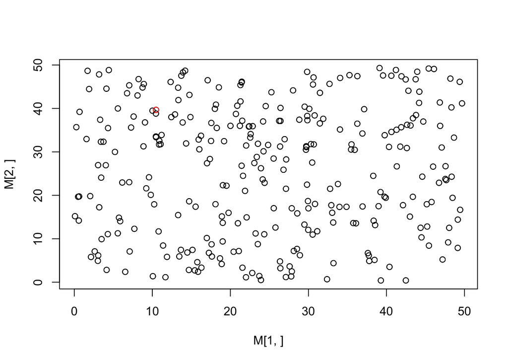

```r
M <- matrix(0,4,People_Size)
X_0<-runif(People_Size,Location_lower_bound ,Location_upper_bound )
Y_0<-runif(People_Size,Location_lower_bound ,Location_upper_bound )
M[c(1,2),]<-M[c(1,2),]+rbind(X_0,Y_0)
Infection_0<-sample(1:People_Size,size = 1)
M[3,Infection_0]<-1
Recover_days<-sample(Illness_Period_Lower_Bound:Illness_Period_Upper_Bound, size = 1, replace = TRUE)
M[4,Infection_0]<-Recover_days
Susceptible <-rep(0,Duration)
Infectious <-rep(0,Duration)
Removed <-rep(0,Duration)
Susceptible[1] <- sum(M[3,]==0)
Infectious[1] <-sum(M[3,]==1)
Removed[1] <-sum(M[3,]==2)
Cured<-c()
plot(M[1,],M[2,])
points(x=M[1,which(M[3,]==2)],
       y=M[2,which(M[3,]==2)],
       col="green")
points(x=M[1,which(M[3,]==0)],
       y=M[2,which(M[3,]==0)],
       col="black")
points(x=M[1,which(M[3,]==1)],
       y=M[2,which(M[3,]==1)],
       col="red")
```

Set the random walk function.

It will change the position of each people, that is the row1 and row2 in the matrix M.

```r
#Random_Walk:(input=M)(output=newM)
Random_Walk <- function(M){
  theta = runif(People_Size,0,2*pi)
  random_walk_x <- step_length*cos(theta)
  random_walk_y <- step_length*sin(theta)

  #print(dim(M[c(1,2),]))
  #print(dim(rbind(random_walk_x,random_walk_y)))
  M[c(1,2),]<-M[c(1,2),]+rbind(random_walk_x,random_walk_y)

  ind_x<-union(which(M[1,]<Location_lower_bound),which(M[1,]>Location_upper_bound))
  M[1,ind_x]<-M[1,ind_x]-2*random_walk_x[ind_x]
  ind_y<-union(which(M[2,]<Location_lower_bound),which(M[2,]>Location_upper_bound))
  M[2,ind_y]<-M[2,ind_y]-2*random_walk_y[ind_y]

  return(M)

}
```

In order to check which people are in the infectious radius of the virus carriers, we set the Check_Potentential_People function.

To avoid computing distance between virus carriers and each others, we set the matrix D, which constraints r unit around the virus carriers’ X-Y position.

The output of this function is the potential infected people’s column number in the matrix M.

```r
Check_Potential_People<-function(M_candidate){
  Spread<-which(M_candidate[3,]==1)
  D<-matrix(0,4,length(Spread))
  D[c(1,2),] <- M_candidate[c(1,2),Spread]+ matrix(r,2,length(Spread))
  D[c(3,4),] <- M_candidate[c(1,2),Spread]- matrix(r,2,length(Spread))

  Potential_People<-c()
  if(length(Spread)!=0){
    for(i in 1:length(Spread)){
      Potential<- Reduce(intersect,  list(which(M_candidate[1,]<D[1,i]),
                                          which(M_candidate[1,]>D[3,i]),
                                          which(M_candidate[2,]<D[2,i]),
                                          which(M_candidate[2,]>D[4,i]),
                                          which(M_candidate[3,]==0)
      )
      )

      if(length(Potential)!=0){
        delta_square = as.matrix((M_candidate[c(1,2),Potential]-M_candidate[c(1,2),Spread[i]])^2)
        target<-intersect(which(apply(delta_square,2,sum)< r^2),which(M_candidate[3,Potential]==0))

        Potential_People<-c(Potential_People,Potential[target])
      }
    }
  }
  return(Potential_People)
}
```

To check these peotential infected people’s infection rate, we set this function below.

Assume that the different virus carriers’ spreading is independent.

```r
Check_Infection_Rate<- function(Potential_People){
  #names(table(Potential_People))
  #as.numeric(table(Potential_People))
  I<-as.data.frame(table(Potential_People))
  p<-matrix(0,2,nrow(I) )
  if(nrow(I)!=0) {
    p[1,]<- as.integer(as.character(I[,1]))
    p[2,]<-1-((1-Infection_Rate)^I[,2])
  }
  return(p)
}
```

With the accurate infection rate, this function determine whether these potential infected people to get infected.

If people were infected, we change the feature(row3 in matirx M) and generate the days they become the Removed.

```r
Doing_Infection<-function(p,M_candidate){
  random <- runif(ncol(p),0,1)
  Determine<- p[2,]>random
  Probable_People<-p[1,which(Determine==TRUE)]
  Healthy_People<-which(M_candidate[3,]==0)
  Infection_People <- intersect(Probable_People,Healthy_People)
  M_candidate[3,Infection_People]<-1
  Ill_Days<- sample(Illness_Period_Lower_Bound:Illness_Period_Upper_Bound, size = length(Infection_People),replace = TRUE)
  M_candidate[4,Infection_People]<-Ill_Days
  return(M_candidate)
}
```

This function is to check whether people become Removed from Infectious.

```r
Check_Cured <- function(M) {
  remove_people<-intersect(which(M[4,]==0),which(M[3,]==1))
  Cured <- c(Cured,remove_people)
  return(Cured)
}
```

It is the simulation part below.

```r
for(i in 1:Duration){
  M<-Random_Walk(M)
  Potential_People<-Check_Potential_People(M) #return is the position
  if(length(Potential_People)!=0){
    Infection_Rate_Matrix <- Check_Infection_Rate(Potential_People)
    M<- Doing_Infection(Infection_Rate_Matrix,M)
  }
  Cured<-Check_Cured(M)
  if(length(Cured)!=0){
    M[3,Cured]<-2
  }


  Susceptible_Num <- sum(M[3,]==0)
  Infectious_Num  <-sum(M[3,]==1)
  Removed_Num<-sum(M[3,]==2)

  Susceptible[i] <- Susceptible_Num
  Infectious[i] <-Infectious_Num
  Removed[i] <-Removed_Num
  m<-which(M[3,]==1)
  M[4,m]<-M[4,m]-1

  #(Below plot the scattered infectious/suspectible/removed)
  #plot(M[1,],M[2,])
  #points(x=M[1,which(M[3,]==2)],
         #y=M[2,which(M[3,]==2)],
         #col="green")
  #points(x=M[1,which(M[3,]==0)],
         #y=M[2,which(M[3,]==0)],
         #col="black")
  #points(x=M[1,which(M[3,]==1)],
         #y=M[2,which(M[3,]==1)],
         #col="red")

}
```

The graph indicates the propotion of each group with time.

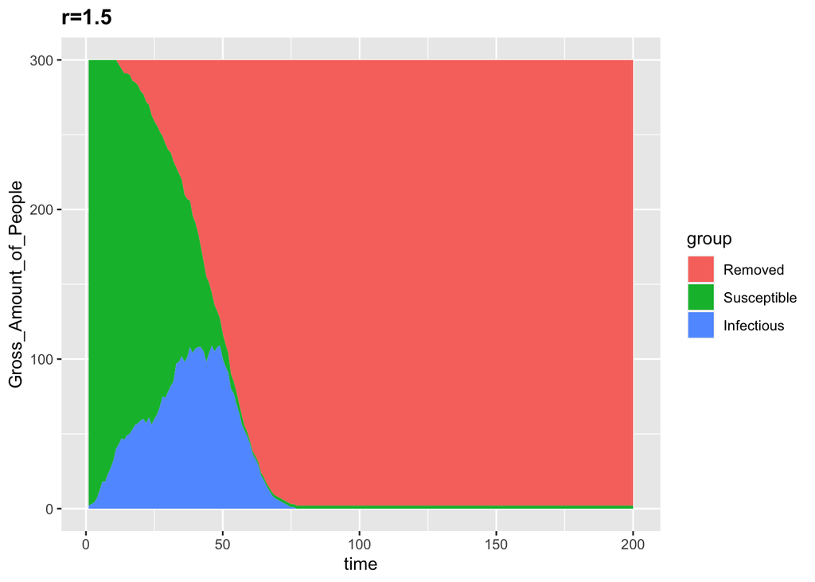

```r
# Packages
library(ggplot2)
library(dplyr)
# create data
time <- c(1:Duration ) # x Axis
Gross_Amount_of_People <- c(Susceptible,Infectious,Removed)              # y Axis
group <-rep( c("Susceptible", "Infectious" ,"Removed" ) , each=Duration)        # group, one shape per group
data <- data.frame(time, Gross_Amount_of_People , group)

# stacked area chart
data$group <- factor(data$group , levels=c("Removed", "Susceptible" , "Infectious") )
Graph <- ggplot(data, aes(x=time, y=Gross_Amount_of_People,  fill=group)) +
  geom_area()
Graph + ggtitle("r=1.5")+
  theme(plot.title = element_text(lineheight=1.2, face="bold"))
```

## Case2

In case2, we only change the infectious radius from 1.5 to 3.

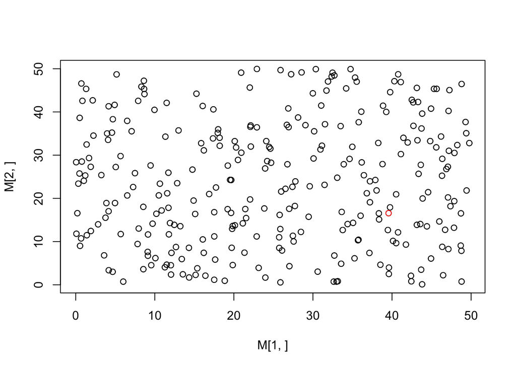

```r
People_Size<-300
Illness_Period_Lower_Bound<-7
Illness_Period_Upper_Bound<-21
Duration <- 200
r=3
Infection_Rate<-0.7
Location_upper_bound <- 50
Location_lower_bound <- 0
step_length <- 2

M <- matrix(0,4,People_Size)
X_0<-runif(People_Size,Location_lower_bound ,Location_upper_bound )
Y_0<-runif(People_Size,Location_lower_bound ,Location_upper_bound )
M[c(1,2),]<-M[c(1,2),]+rbind(X_0,Y_0)
Infection_0<-sample(1:People_Size,size = 1)
M[3,Infection_0]<-1
Recover_days<-sample(Illness_Period_Lower_Bound:Illness_Period_Upper_Bound, size = 1, replace = TRUE)
M[4,Infection_0]<-Recover_days
Susceptible <-rep(0,Duration)
Infectious <-rep(0,Duration)
Removed <-rep(0,Duration)
Susceptible[1] <- sum(M[3,]==0)
Infectious[1] <-sum(M[3,]==1)
Removed[1] <-sum(M[3,]==2)
Cured<-c()
plot(M[1,],M[2,])
points(x=M[1,which(M[3,]==2)],
       y=M[2,which(M[3,]==2)],
       col="green")
points(x=M[1,which(M[3,]==0)],
       y=M[2,which(M[3,]==0)],
       col="black")
points(x=M[1,which(M[3,]==1)],
       y=M[2,which(M[3,]==1)],
       col="red")
```

```r
for(i in 1:Duration){
  M<-Random_Walk(M)
  Potential_People<-Check_Potential_People(M) #return is the position
  if(length(Potential_People)!=0){
    Infection_Rate_Matrix <- Check_Infection_Rate(Potential_People)
    M<- Doing_Infection(Infection_Rate_Matrix,M)
  }
  Cured<-Check_Cured(M)
  if(length(Cured)!=0){
    M[3,Cured]<-2
  }


  Susceptible_Num <- sum(M[3,]==0)
  Infectious_Num  <-sum(M[3,]==1)
  Removed_Num<-sum(M[3,]==2)

  Susceptible[i] <- Susceptible_Num
  Infectious[i] <-Infectious_Num
  Removed[i] <-Removed_Num
  m<-which(M[3,]==1)
  M[4,m]<-M[4,m]-1

}
```

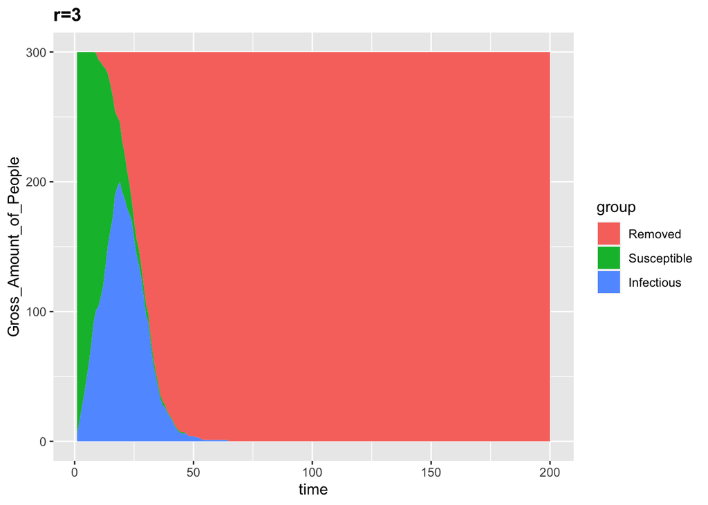

```r
# create data
time <- c(1:Duration ) # x Axis
Gross_Amount_of_People <- c(Susceptible,Infectious,Removed)              # y Axis
group <-rep( c("Susceptible", "Infectious" ,"Removed" ) , each=Duration)        # group, one shape per group
data <- data.frame(time, Gross_Amount_of_People , group)

# stacked area chart
data$group <- factor(data$group , levels=c("Removed", "Susceptible" , "Infectious") )
Graph2 <- ggplot(data, aes(x=time, y=Gross_Amount_of_People,  fill=group)) +
  geom_area()
Graph2 + ggtitle("r=3")+
  theme(plot.title = element_text(lineheight=1.2, face="bold"))
```